# Acute Changes in CEWL as a Function of Temperature: Deceased Lizards

Calvin Davis, Savannah Weaver

2022

# Packages

```r
if (!require("tidyverse")) install.packages("tidyverse")
library("tidyverse") #tidyr, ggplot, dplyr, etc
if (!require("ggpubr")) install.packages("ggpubr")
library("ggpubr") # arrange multi-figures
if (!require("RColorBrewer")) install.packages("RColorBrewer")
library("RColorBrewer") # colors
if (!require("rmdformats")) install.packages("rmdformats")
library("rmdformats") # clean html R markdown format
```

# Background

This code goes through data wrangling, summary statistics, and figures for data on two deceased lizards that we opportunistically studied. Their data are part of a study on the rate of change of cutaneous evaporative water loss (CEWL) in response to temperature change in Western Fence Lizards (*Sceloporus occidentalis*). Data was collected and analyzed by Calvin Davis and Savannah Weaver, and the project was advised by Dr. Emily Taylor at California Polytechnic State University.

# Load Data

## Live Lizzies

Data for average CEWL at each temperature.

```r
live_CEWL_per_temp <- read_rds("Data/CEWL_by_temp_tmt.RDS")
summary(live_CEWL_per_temp)
```

```
##    treatment  rounded_cal_c_temp mean_mean_CEWL      CEWL_sd
##  Control: 2   Min.   :17.00      Min.   : 5.438   Min.   :2.291
##  Cooling:16   1st Qu.:22.00      1st Qu.: 6.972   1st Qu.:3.281
##  Heating:18   Median :26.50      Median :13.755   Median :6.132
##               Mean   :26.06      Mean   :12.697   Mean   :5.583
##               3rd Qu.:30.00      3rd Qu.:17.480   3rd Qu.:7.707
##               Max.   :34.00      Max.   :19.647   Max.   :8.726
##     CEWL_min         CEWL_max           n             CEWL_sem
##  Min.   : 2.422   Min.   :10.90   Min.   : 6.000   Min.   :0.7246
##  1st Qu.: 3.400   1st Qu.:15.40   1st Qu.: 9.000   1st Qu.:1.0367
##  Median : 6.198   Median :24.09   Median :10.000   Median :1.9855
##  Mean   : 6.184   Mean   :21.93   Mean   : 9.528   Mean   :1.8429
##  3rd Qu.: 8.357   3rd Qu.:28.38   3rd Qu.:10.250   3rd Qu.:2.4522
##  Max.   :10.775   Max.   :30.45   Max.   :11.000   Max.   :3.5059
```

## CEWL

Get filenames:

```r
# make a list of file names of all data to load in
filenames_dead_aquaflux <- (list.files(path = "./Data/dead lizards/R format",
                                 pattern = "csv"))[1:6]
```

Make a function that will read in the data from each csv, name and organize the data correctly.

Variables:

- time sec = time recording from evaporimeter
- CEWL_g_m2h = cutaneous evaporative water loss
- msmt_temp_C = ambient temperature in Celsius at the time of CEWL measurement
- msmt_RH_percent = % relative ambient humidity at the time of CEWL measurement

```r
read_dead_CEWL_file <- function(filename_dead) {

   # save helpful info
   name <- trimws(substr(filename_dead, 6, 13))
   treatment <- trimws(substr(filename_dead, 15, 21))

   ## load file
   dat_dead <- read.csv(file.path("./Data/dead lizards/R format", filename_dead),
                        header = TRUE) %>%
      # select only the relevant values
      dplyr::select(time_sec = 'Time..sec.',
                    CEWL_g_m2h = 'Flux..g..m2h..',
                    msmt_temp_C = 'AmbT..C.',
                    msmt_RH_percent = 'AmbRH....'
                    ) %>%
      # use filename info
      dplyr::mutate(lizard_ID = (name),
                    treatment = (treatment))
   # return the dataframe for that single csv file
   dat_dead

}
```

Apply function to all files, compile, and incorporate timing:

```r
# apply function to get data from all csvs
all_dead_CEWL_data <- lapply(filenames_dead_aquaflux, read_dead_CEWL_file) %>%
   # paste all data files together into one df by row
   reduce(rbind) %>%
   # properly format data classes
   mutate(lizard_ID = as.factor(lizard_ID),
          treatment = as.factor(treatment),
          liz_tmt = as.factor(paste(substr(lizard_ID, 8, 8), treatment)),
          time_sec = floor(as.numeric(time_sec)),
          CEWL_g_m2h = as.numeric(CEWL_g_m2h),
          msmt_temp_C = as.numeric(msmt_temp_C),
          msmt_RH_percent = as.numeric(msmt_RH_percent))

summary(all_dead_CEWL_data)
```

```
##     time_sec       CEWL_g_m2h     msmt_temp_C    msmt_RH_percent
##  Min.   :  0.0   Min.   : 0.13   Min.   :25.50   Min.   :45.90
##  1st Qu.:225.0   1st Qu.:11.40   1st Qu.:25.80   1st Qu.:47.30
##  Median :450.0   Median :27.34   Median :26.20   Median :48.20
##  Mean   :449.7   Mean   :26.76   Mean   :26.25   Mean   :48.03
##  3rd Qu.:675.0   3rd Qu.:40.56   3rd Qu.:26.70   3rd Qu.:48.70
##  Max.   :900.0   Max.   :67.07   Max.   :27.10   Max.   :50.10
##     lizard_ID      treatment         liz_tmt
##  lizard A:2655   control:1770   A control:885
##  lizard D:2655   cooling:1770   A cooling:885
##                  heating:1770   A heating:885
##                                 D control:885
##                                 D cooling:885
##                                 D heating:885
```

### Equilibration

The evaporimeter also takes 1-2 minutes to equilibrate to the lizard at the start of each time series, so we want to estimate when equilibration was complete for each lizard.

Previously, we found the peak during the equilibrium period, then cut out that data up to 60 seconds after the peak. However, not all the data for the dead lizards decreased again, so we will just filter out the first 90 seconds (1.5 minutes).

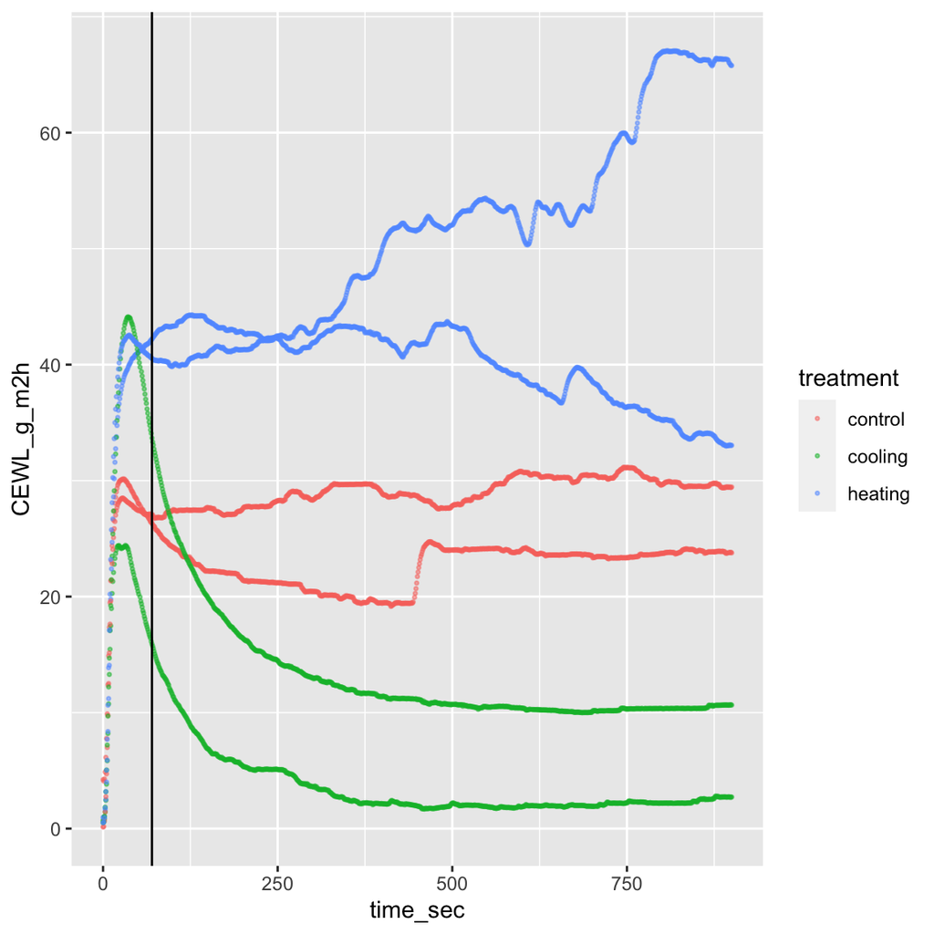

```r
ggplot(data = all_dead_CEWL_data,
       aes(x = time_sec,
           y = CEWL_g_m2h,
           color = treatment)) +
   geom_point(size = 0.5, alpha = 0.5) +
   geom_vline(xintercept = 70)
```

filter:

```r
dead_CEWL_data_filtered <- all_dead_CEWL_data %>%
  dplyr::filter(time_sec > 89)
```

### Time Series df

add start times/ actual times and relative CEWL:

```r
start_CEWL <- dead_CEWL_data_filtered %>%
  dplyr::filter(time_sec == 90) %>%
  dplyr::select(lizard_ID, treatment,
                start_CEWL = CEWL_g_m2h)

CEWL_time <- dead_CEWL_data_filtered %>%
          # get actual time for joining temperature data
  mutate(start_time = case_when(lizard_ID == "lizard A" & treatment == "control" ~
                                  "15:07:15",
                                lizard_ID == "lizard A" & treatment == "cooling" ~
                                  "16:16:25",
                                lizard_ID == "lizard A" & treatment == "heating" ~
                                  "17:01:05",
                                lizard_ID == "lizard D" & treatment == "control" ~
                                  "14:42:10",
                                lizard_ID == "lizard D" & treatment == "cooling" ~
                                  "16:39:32",
                                lizard_ID == "lizard D" & treatment == "heating" ~
                                  "15:38:19"
                                  ),
         start_date_time = as.POSIXct(paste("2022-06-29", start_time, sep = " "),
                                      format = "%Y-%m-%d %H:%M:%S"),
         date_time = start_date_time + time_sec) %>%
  left_join(start_CEWL, by = c("lizard_ID", "treatment")) %>%
  mutate(relative_CEWL = CEWL_g_m2h - start_CEWL,
         # get diff time format
         time_min = time_sec/60) %>%
  dplyr::select(lizard_ID, treatment, liz_tmt,
                time_min, date_time,
                CEWL_g_m2h, relative_CEWL)

summary(CEWL_time)
```

```
##     lizard_ID      treatment         liz_tmt       time_min
##  lizard A:2388   control:1592   A control:796   Min.   : 1.500
##  lizard D:2388   cooling:1592   A cooling:796   1st Qu.: 4.879
##                  heating:1592   A heating:796   Median : 8.250
##                                 D control:796   Mean   : 8.251
##                                 D cooling:796   3rd Qu.:11.621
##                                 D heating:796   Max.   :15.000
##    date_time                        CEWL_g_m2h    relative_CEWL
##  Min.   :2022-06-29 14:43:40.00   Min.   : 1.68   Min.   :-18.130
##  1st Qu.:2022-06-29 15:15:29.75   1st Qu.:10.79   1st Qu.:-10.443
##  Median :2022-06-29 16:05:37.00   Median :27.07   Median : -1.450
##  Mean   :2022-06-29 16:02:22.70   Mean   :26.55   Mean   : -2.882
##  3rd Qu.:2022-06-29 16:47:46.25   3rd Qu.:40.73   3rd Qu.:  1.390
##  Max.   :2022-06-29 17:16:05.00   Max.   :67.07   Max.   : 26.790
```

## Thermocouples

Get filenames:

```r
# make a list of file names of all data to load in
filenames_dead_TC <- (list.files(path = "./Data/dead lizards/TC",
                                 pattern = "csv"))[2:6]
```

Make a function that will read in the data from each csv, name and organize the data correctly.

```r
read_dead_TC_file <- function(filename_dead) {

   # save helpful info
   name <- trimws(substr(filename_dead, 12, 12))
   treatment <- trimws(substr(filename_dead, 13, 20))

   ## load file
   dat_dead <- read.csv(file.path("./Data/dead lizards/TC", filename_dead),
                        header = TRUE) %>%
      # use filename info
      dplyr::mutate(lizard_ID = paste("lizard",name, sep = " "),
                    treatment = (treatment))
   # return the dataframe for that single csv file
   dat_dead
}
```

Apply function to all files, compile, and incorporate timing:

```r
# apply function to get data from all csvs
all_dead_TC_data <- lapply(filenames_dead_TC, read_dead_TC_file) %>%
   # paste all data files together into one df by row
   reduce(rbind) %>%
   # get rid of empty cells
   dplyr::filter(complete.cases(Time, Value)) %>%
   # properly format data classes
   mutate(lizard_ID = as.factor(lizard_ID),
          treatment = as.factor(treatment),
          date_time = as.POSIXct(paste(Date, Time),
                                 format = "%m/%d/%y %H:%M:%S")) %>%
  dplyr::select(date_time, lizard_ID, treatment, temp_C = Value)

summary(all_dead_TC_data)
```

```
##    date_time                         lizard_ID    treatment      temp_C
##  Min.   :2022-06-29 14:40:23.00   lizard A:38   control:36   Min.   :11.20
##  1st Qu.:2022-06-29 15:11:15.00   lizard D:58   cooling:37   1st Qu.:21.30
##  Median :2022-06-29 15:49:22.00                 heating:23   Median :25.60
##  Mean   :2022-06-29 15:48:17.41                              Mean   :24.90
##  3rd Qu.:2022-06-29 16:24:54.00                              3rd Qu.:27.57
##  Max.   :2022-06-29 16:54:53.00                              Max.   :36.70
```

### TC Calibration

The thermocouples tend to drift 1-2 C off of the true temperature, so we collected reference data to make a calibration curve for each one.

Get all the data and organize:

```r
calibration_logger <- read.csv("./Data/dead lizards/TC/thermocouple_calibration.csv",  header = TRUE) %>%
  mutate(date_time = round(as.POSIXct(paste(Date, Time),
                                      format = "%m/%d/%y %H:%M:%S"),
                           "mins"))

calibration_reference <- read.csv("./Data/dead lizards/TC/thermocouple_reference.csv",  header = TRUE)  %>%
   mutate(date = "6/21/22",
          date_time = as.POSIXct(paste(date, time), format = "%m/%d/%y %H:%M")) %>%
  dplyr::select(date_time, ref_temp_C)

calibration_A <- calibration_logger %>% # port 1 = TC A = lizard A
  dplyr::select(date_time, temp_C = Value, Unit) %>%
  left_join(calibration_reference, by = 'date_time') %>%
  dplyr::filter(complete.cases(ref_temp_C))

calibration_D <- calibration_logger %>% # port 4 = TC D = lizard D
  dplyr::select(date_time, temp_C = Value.3, Unit.3) %>%
  left_join(calibration_reference, by = 'date_time') %>%
  dplyr::filter(complete.cases(ref_temp_C))
```

Next, calculate and save regression curves:

```r
# calculate regression curves
regression_a_dead <- lm(data = calibration_A,
                        temp_C ~ ref_temp_C)
regression_d_dead <- lm(data = calibration_D,
                        temp_C ~ ref_temp_C)

# store calibration values
a_intercept <- coef(regression_a_dead)[1]
a_slope <- coef(regression_a_dead)[2]
d_intercept <- coef(regression_d_dead)[1]
d_slope <- coef(regression_d_dead)[2]
```

Finally, use calibration curves to correct the data we measured:

```r
all_dead_TC_data_calibrated <- all_dead_TC_data %>%
   mutate(calibrated_cloacal_temp_C = case_when(lizard_ID == "lizard A" ~
                                                  (a_intercept + temp_C*a_slope),
                                                lizard_ID == "lizard D" ~
                                                  (d_intercept + temp_C*d_slope))
                  )
summary(all_dead_TC_data_calibrated)
```

```
##    date_time                         lizard_ID    treatment      temp_C
##  Min.   :2022-06-29 14:40:23.00   lizard A:38   control:36   Min.   :11.20
##  1st Qu.:2022-06-29 15:11:15.00   lizard D:58   cooling:37   1st Qu.:21.30
##  Median :2022-06-29 15:49:22.00                 heating:23   Median :25.60
##  Mean   :2022-06-29 15:48:17.41                              Mean   :24.90
##  3rd Qu.:2022-06-29 16:24:54.00                              3rd Qu.:27.57
##  Max.   :2022-06-29 16:54:53.00                              Max.   :36.70
##  calibrated_cloacal_temp_C
##  Min.   :12.22
##  1st Qu.:22.44
##  Median :26.78
##  Mean   :26.08
##  3rd Qu.:28.84
##  Max.   :38.14
```

### Time Temp df

```r
CEWL_time_temp <- CEWL_time %>%
   left_join(all_dead_TC_data_calibrated,
             by = c('date_time', 'lizard_ID', 'treatment')) %>%
   dplyr::select(-temp_C)

summary(CEWL_time_temp)
```

```
##     lizard_ID      treatment         liz_tmt       time_min
##  lizard A:2388   control:1592   A control:796   Min.   : 1.500
##  lizard D:2388   cooling:1592   A cooling:796   1st Qu.: 4.879
##                  heating:1592   A heating:796   Median : 8.250
##                                 D control:796   Mean   : 8.251
##                                 D cooling:796   3rd Qu.:11.621
##                                 D heating:796   Max.   :15.000
##
##    date_time                        CEWL_g_m2h    relative_CEWL
##  Min.   :2022-06-29 14:43:40.00   Min.   : 1.68   Min.   :-18.130
##  1st Qu.:2022-06-29 15:15:29.75   1st Qu.:10.79   1st Qu.:-10.443
##  Median :2022-06-29 16:05:37.00   Median :27.07   Median : -1.450
##  Mean   :2022-06-29 16:02:22.70   Mean   :26.55   Mean   : -2.882
##  3rd Qu.:2022-06-29 16:47:46.25   3rd Qu.:40.73   3rd Qu.:  1.390
##  Max.   :2022-06-29 17:16:05.00   Max.   :67.07   Max.   : 26.790
##
##  calibrated_cloacal_temp_C
##  Min.   :12.52
##  1st Qu.:20.69
##  Median :26.33
##  Mean   :24.41
##  3rd Qu.:27.03
##  Max.   :34.88
##  NA's   :4711
```

```r
nrow(CEWL_time_temp) - 4711 # this is the # of temperature measurements we were able to apply
```

```
## [1] 65
```

## Subset Tmts/Individual

We did all 3 treatments on both individuals… For lizard A, we did control, cooling, then heating. For lizard D, we did control, heating, then cooling.

We’ve decided that we will present each lizard’s control data, and the first treatment each lizard did. So, cooling for lizard A and heating for lizard D.

```r
A_ctrl_cool <- CEWL_time_temp %>%
  dplyr::filter(lizard_ID == "lizard A") %>%
  dplyr::filter(treatment %in% c("cooling", "control"))
summary(A_ctrl_cool)
```

```
##     lizard_ID      treatment        liz_tmt       time_min
##  lizard A:1592   control:796   A control:796   Min.   : 1.500
##  lizard D:   0   cooling:796   A cooling:796   1st Qu.: 4.879
##                  heating:  0   A heating:  0   Median : 8.250
##                                D control:  0   Mean   : 8.251
##                                D cooling:  0   3rd Qu.:11.621
##                                D heating:  0   Max.   :15.000
##
##    date_time                        CEWL_g_m2h    relative_CEWL
##  Min.   :2022-06-29 15:08:45.00   Min.   : 1.68   Min.   :-11.170
##  1st Qu.:2022-06-29 15:15:29.75   1st Qu.: 2.21   1st Qu.:-10.640
##  Median :2022-06-29 15:50:05.00   Median :16.00   Median : -5.370
##  Mean   :2022-06-29 15:50:05.03   Mean   :12.94   Mean   : -5.903
##  3rd Qu.:2022-06-29 16:24:40.25   3rd Qu.:23.47   3rd Qu.: -1.280
##  Max.   :2022-06-29 16:31:25.00   Max.   :24.84   Max.   :  0.000
##
##  calibrated_cloacal_temp_C
##  Min.   :12.52
##  1st Qu.:16.65
##  Median :26.13
##  Mean   :22.34
##  3rd Qu.:26.64
##  Max.   :27.75
##  NA's   :1567
```

```r
D_ctrl_heat <- CEWL_time_temp %>%
  dplyr::filter(lizard_ID == "lizard D") %>%
  dplyr::filter(treatment %in% c("heating", "control"))
summary(D_ctrl_heat)
```

```
##     lizard_ID      treatment        liz_tmt       time_min
##  lizard A:   0   control:796   A control:  0   Min.   : 1.500
##  lizard D:1592   cooling:  0   A cooling:  0   1st Qu.: 4.879
##                  heating:796   A heating:  0   Median : 8.250
##                                D control:796   Mean   : 8.250
##                                D cooling:  0   3rd Qu.:11.621
##                                D heating:796   Max.   :15.000
##
##    date_time                        CEWL_g_m2h    relative_CEWL
##  Min.   :2022-06-29 14:43:40.00   Min.   :27.01   Min.   :-0.45
##  1st Qu.:2022-06-29 14:50:25.75   1st Qu.:29.40   1st Qu.: 1.39
##  Median :2022-06-29 15:18:29.50   Median :35.49   Median : 2.83
##  Mean   :2022-06-29 15:18:29.52   Mean   :40.37   Mean   : 6.63
##  3rd Qu.:2022-06-29 15:46:33.25   3rd Qu.:52.03   3rd Qu.:11.75
##  Max.   :2022-06-29 15:53:19.00   Max.   :67.07   Max.   :26.79
##
##  calibrated_cloacal_temp_C
##  Min.   :21.52
##  1st Qu.:26.93
##  Median :27.13
##  Mean   :28.00
##  3rd Qu.:29.22
##  Max.   :34.88
##  NA's   :1565
```

```r
CEWL_time_temp_subset <- D_ctrl_heat %>%
  rbind(A_ctrl_cool)
summary(CEWL_time_temp_subset)
```

```
##     lizard_ID      treatment         liz_tmt       time_min
##  lizard A:1592   control:1592   A control:796   Min.   : 1.500
##  lizard D:1592   cooling: 796   A cooling:796   1st Qu.: 4.879
##                  heating: 796   A heating:  0   Median : 8.250
##                                 D control:796   Mean   : 8.251
##                                 D cooling:  0   3rd Qu.:11.621
##                                 D heating:796   Max.   :15.000
##
##    date_time                        CEWL_g_m2h    relative_CEWL
##  Min.   :2022-06-29 14:43:40.00   Min.   : 1.68   Min.   :-11.1700
##  1st Qu.:2022-06-29 15:05:51.25   1st Qu.:17.58   1st Qu.: -5.3700
##  Median :2022-06-29 15:31:02.00   Median :25.93   Median : -0.2800
##  Mean   :2022-06-29 15:34:17.27   Mean   :26.66   Mean   :  0.3639
##  3rd Qu.:2022-06-29 15:59:28.00   3rd Qu.:33.33   3rd Qu.:  2.8250
##  Max.   :2022-06-29 16:31:25.00   Max.   :67.07   Max.   : 26.7900
##
##  calibrated_cloacal_temp_C
##  Min.   :12.52
##  1st Qu.:24.83
##  Median :26.69
##  Mean   :25.28
##  3rd Qu.:27.26
##  Max.   :34.88
##  NA's   :3132
```

# Stats

Compare CEWL at a common body temp to the live lizards.

## Prep Dead Data

```r
mean_CEWL_temp_dead <- CEWL_time_temp_subset %>%
  mutate(rounded_cal_c_temp = round(calibrated_cloacal_temp_C, 0),
         # need to update format to join live lizard data
         treatment = factor(treatment, labels = c("Control", "Cooling", "Heating"))
         ) %>%
  dplyr::filter(complete.cases(rounded_cal_c_temp)) %>%
  group_by(treatment, rounded_cal_c_temp) %>%
  summarise(mean_CEWL = mean(CEWL_g_m2h)
            #n = n()
            )
mean_CEWL_temp_dead
```

```
## # A tibble: 25 × 3
## # Groups:   treatment [3]
##    treatment rounded_cal_c_temp mean_CEWL
##    <fct>                  <dbl>     <dbl>
##  1 Control                   26     20.8
##  2 Control                   27     27.2
##  3 Cooling                   13      2.30
##  4 Cooling                   14      1.99
##  5 Cooling                   15      1.99
##  6 Cooling                   16      1.85
##  7 Cooling                   17      1.9
##  8 Cooling                   18      2.11
##  9 Cooling                   21      3.37
## 10 Cooling                   23      5.09
## # … with 15 more rows
```

```r
summary(mean_CEWL_temp_dead)
```

```
##    treatment  rounded_cal_c_temp   mean_CEWL
##  Control: 2   Min.   :13.0       Min.   : 1.85
##  Cooling:10   1st Qu.:21.0       1st Qu.: 3.37
##  Heating:13   Median :25.0       Median :40.23
##               Mean   :24.6       Mean   :29.40
##               3rd Qu.:29.0       3rd Qu.:51.67
##               Max.   :35.0       Max.   :65.86
```

## Join Dead & Live

### For Stats

```r
CEWL_per_temp_compare <- mean_CEWL_temp_dead %>%
  dplyr::select(treatment,
                rounded_cal_c_temp,
                mean_CEWL_dead = mean_CEWL) %>%
  left_join(
    live_CEWL_per_temp,
    by = c('treatment', 'rounded_cal_c_temp')
  ) %>%
  mutate(
    dead_minus_live_diff = mean_CEWL_dead - mean_mean_CEWL
  ) %>%
  dplyr::filter(complete.cases(dead_minus_live_diff))
```

### For Figs

```r
# prep ded
mean_CEWL_temp_dead_pretty <- mean_CEWL_temp_dead %>%
  mutate(lizards = "Deceased")

# prep live
live_CEWL_per_temp_pretty <- live_CEWL_per_temp %>%
  dplyr::select(treatment, rounded_cal_c_temp,
                mean_CEWL = mean_mean_CEWL) %>%
  mutate(lizards = "Live")

CEWL_per_temp_compare_pretty <- mean_CEWL_temp_dead_pretty %>%
  rbind(live_CEWL_per_temp_pretty) %>%
  mutate(lizards = factor(lizards, levels = c("Live", "Deceased")))

summary(CEWL_per_temp_compare_pretty)
```

```
##    treatment  rounded_cal_c_temp   mean_CEWL          lizards
##  Control: 4   Min.   :13.00      Min.   : 1.850   Live    :36
##  Cooling:26   1st Qu.:22.00      1st Qu.: 6.253   Deceased:25
##  Heating:31   Median :26.00      Median :15.180
##               Mean   :25.46      Mean   :19.543
##               3rd Qu.:30.00      3rd Qu.:19.647
##               Max.   :35.00      Max.   :65.860
```

```r
# prep live liz data
live_CEWL_per_temp_sub <- live_CEWL_per_temp %>%
  mutate(liz_tmt = paste("Live", treatment, sep = " - ")) %>%
  dplyr::select(
    liz_tmt,
    treatment,
    clo_temp = rounded_cal_c_temp,
    CEWL_g_m2h = mean_mean_CEWL,
    CEWL_sem
  ) %>%
  # remove skewed pt bc of few indivs measured
  dplyr::filter(!(clo_temp == 16 & treatment == "Heating"))

raw_dead_vs_CEWL_per_temp_live <- CEWL_time_temp_subset %>%
  # get rid of CEWL that's not linked to Tb
  # by doing this, we essentially recorded CEWL once every minute
  dplyr::filter(complete.cases(calibrated_cloacal_temp_C)) %>%
  # subset to common/pertinent cols only
  dplyr::select(
    liz_tmt,
    treatment,
    clo_temp = calibrated_cloacal_temp_C,
    CEWL_g_m2h
  ) %>%
  mutate(CEWL_sem = NA) %>%
  # ADD LIVE LIZARD DATA
  rbind(live_CEWL_per_temp_sub)
```

## Summarize

```r
CEWL_per_temp_compare %>%
  group_by(treatment) %>%
  summarise(mean_diff = mean(dead_minus_live_diff),
            sd_diff = sd(dead_minus_live_diff),
            max_diff = max(dead_minus_live_diff),
            min_diff = min(dead_minus_live_diff),
            n = n()) %>%
  mutate(sem_diff = sd_diff/sqrt(n))
```

```
## # A tibble: 3 × 7
##   treatment mean_diff sd_diff max_diff min_diff     n sem_diff
##   <fct>         <dbl>   <dbl>    <dbl>    <dbl> <int>    <dbl>
## 1 Control      12.1     NA       12.1     12.1      1   NA
## 2 Cooling      -0.576    1.33     1.12    -2.13     4    0.666
## 3 Heating      30.7      6.15    43.5     23.3     12    1.78
```

# Figures

## color

```r
#cool <- c(brewer.pal(11, "Spectral")[c(10)])
#heat <- c(brewer.pal(11, "Spectral")[c(1)])
#control1 <- c(brewer.pal(11, "Spectral")[c(7)])
#control2 <- c(brewer.pal(11, "Spectral")[c(4)])

control <- c(brewer.pal(9, "Greys")[c(5)])
cool  <- c(brewer.pal(11, "RdBu")[c(11)])
heat  <- c(brewer.pal(11, "RdBu")[c(2)])
control1  <- c(brewer.pal(11, "RdBu")[c(8)]) # cooling lizard
control2  <- c(brewer.pal(11, "RdBu")[c(4)]) # heating lizard
```

## * CEWL (relative) ~ time

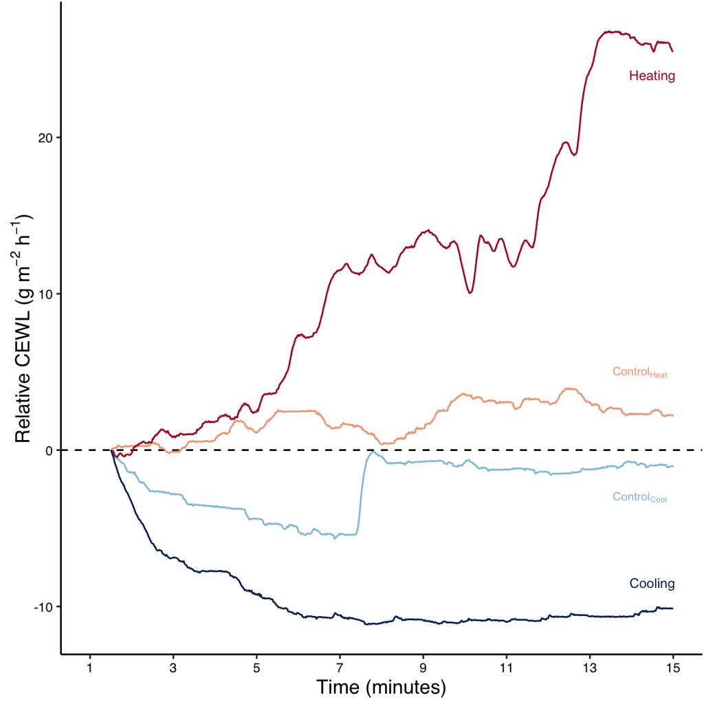

```r
ggplot(CEWL_time_temp_subset) +

  geom_hline(yintercept = 0, size = 0.5,
              linetype = "dashed", color = "black") +

  geom_line(aes(x= time_min,
                  y = relative_CEWL,
                  color = liz_tmt)) +

   theme_classic() +
   theme(text = element_text(color = "black",
                            family = "sans",
                            size = 12),
        axis.text = element_text(color = "black",
                                 family = "sans",
                                 size = 8),
        legend.text = element_text(color = "black",
                                 family = "sans",
                                 size = 12),
        axis.title.y = element_text(vjust = -1),
        legend.position = "none",
        plot.margin = margin(t = 1, r = 1, b = 4, l = 1, unit = "pt")) +

   scale_color_manual(values = c("A control" = control1,
                                 "D control" = control2,
                                     "A cooling" = cool,
                                     "D heating" = heat),
                      name = "Treatment") +
  scale_x_continuous(limits = c(1, 15),
                      breaks = seq(1, 15, 2)) +

   annotate("text", label = "Cooling",
            x = 14.5, y = -8.5, size = 2.9, color = cool) +
   annotate("text", label = "Control[Cool]", parse = T,
            x = 14.2, y = -3, size = 2.5, color = control1) +

   annotate("text", label = "Heating",
            x = 14.5, y = 24, size = 2.9, color = heat) +
   annotate("text", label = "Control[Heat]", parse = T,
            x = 14.2, y = 5, size = 2.5, color = control2) +

   labs(x = "Time (minutes)" ,
        y = bquote('Relative CEWL (g '*m^-2*' '*h^-1*')')) -> CEWLr_time
CEWLr_time
```

```r
ggsave(filename = "CEWL_relative_time_dead.pdf",
       plot = CEWLr_time,
       path = "./Results_Figures",
       device = "pdf",
       dpi = 600,
       units = "mm",
       width = 150, height = 100)
```

## CEWL (raw) ~ cloacal temperature

note, there is a warning that 3132 rows were removed because they do not have cloacal temperature values

```
## Warning: Removed 3132 rows containing non-finite values (`stat_smooth()`).
```

```
## Warning: Removed 3132 rows containing missing values (`geom_point()`).
```

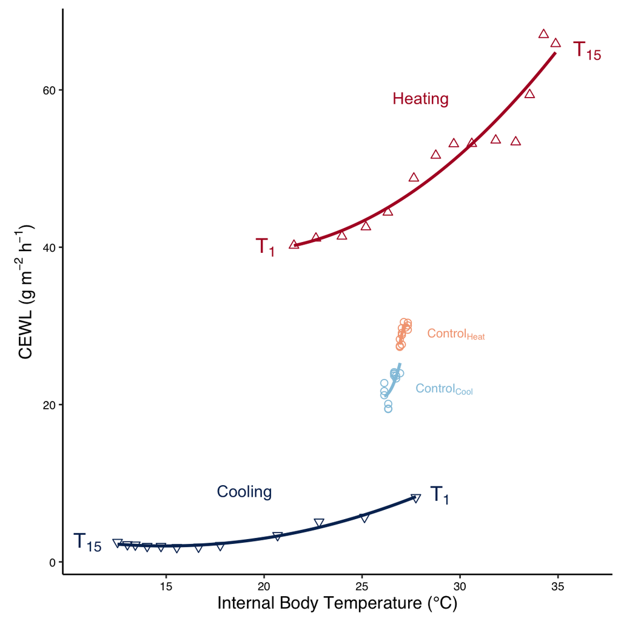

```r
ggplot(CEWL_time_temp_subset) +
   geom_point(aes(x = (calibrated_cloacal_temp_C),
       y = CEWL_g_m2h,
       shape = treatment,
       color = liz_tmt),
       size = 2,
       alpha = 1) +
  geom_smooth(aes(x = (calibrated_cloacal_temp_C),
       y = CEWL_g_m2h,
       color = liz_tmt),
       method = "lm",
        formula = y ~ poly(x, 2),
               size = 1,
               se = F) +
  scale_x_continuous(limits = c(11, 36.5),
                     breaks = c(seq(15, 35, 5)),
                     labels = c(seq(15, 35, 5))) +

  # control group
   annotate("text", x = 29.8, y = 29, label = "Control[Heat]", parse = T,
           size = 3, family = "sans", color = control2) +
  annotate("text", x = 29.2, y = 22, label = "Control[Cool]", parse = T,
           size = 3, family = "sans", color = control1) +

  # annotations for cooling group
  annotate("text", label = "Cooling",
            x = 19, y = 9, size = 4, color = cool) +
  annotate("text", x = 11, y = 2.5, label = "T[15]", parse = T,
           size = 5, family = "sans", color = cool) +
  annotate("text", x = 29, y = 8.5, label = "T[1]", parse = T,
           size = 5, family = "sans", color = cool) +

  # annotations for heating group
  annotate("text", label = "Heating",
            x = 28, y = 59, size = 4, color = heat) +
   annotate("text", x = 20.1, y = 40, label = "T[1]", parse = T,
           size = 5, family = "sans", color = heat) +
   annotate("text", x = 36.5, y = 65, label = "T[15]", parse = T,
           size = 5, family = "sans", color = heat) +

   theme_classic() +
   theme(text = element_text(color = "black",
                            family = "sans",
                            size = 12),
        axis.text = element_text(color = "black",
                                 family = "sans",
                                 size = 8),
        legend.text = element_text(color = "black",
                                 family = "sans",
                                 size = 12),
        legend.position = "none",
        plot.margin = margin(t = 6, r = 6, b = 6, l = 10, unit = "pt")) +

   scale_color_manual(values = c("A control" = control1,
                                 "D control" = control2,
                                     "A cooling" = cool,
                                     "D heating" = heat),
                      name = "Treatment") +
  scale_shape_manual(values = c(21,25,24),
                     name = "Treatment") +

   labs(x = "Internal Body Temperature (°C)" ,
        y = bquote('CEWL (g '*m^-2*' '*h^-1*')'),
        se = FALSE) -> CEWL_ctemp
CEWL_ctemp
```

```r
ggsave(filename = "CEWL_temp_dead.pdf",
       plot = CEWL_ctemp,
       path = "./Results_Figures",
       device = "pdf",
       dpi = 600,
       units = "mm",
       width = 140, height = 200)
```

## * CEWL ~ temp (mean live vs raw ded)

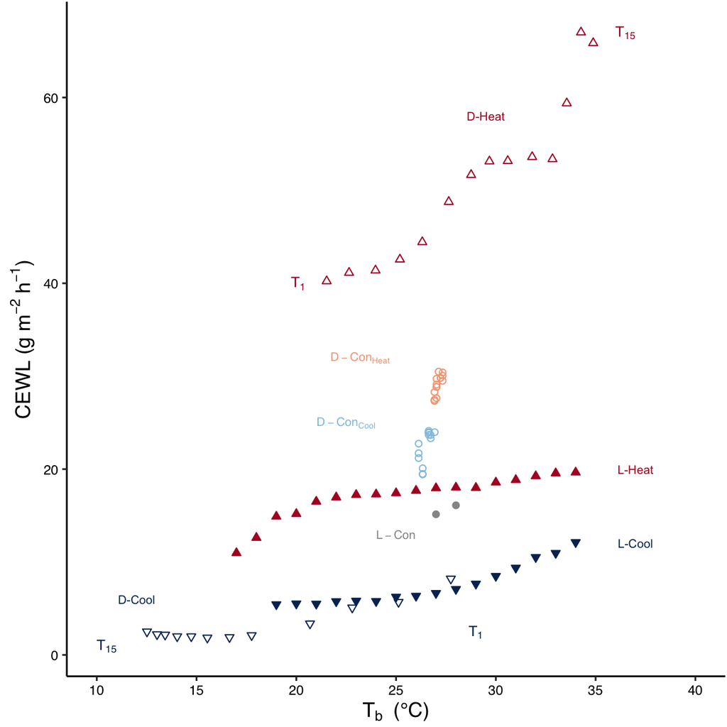

```r
ggplot(raw_dead_vs_CEWL_per_temp_live) +
  geom_point(
    aes(
      x = clo_temp,
      y = CEWL_g_m2h,
      color = liz_tmt,
      fill = liz_tmt,
      shape = liz_tmt
    )
  ) +

   theme_classic() +
   theme(text = element_text(color = "black",
                            family = "sans",
                            size = 12),
        axis.text = element_text(color = "black",
                                 family = "sans",
                                 size = 8),
        legend.text = element_text(color = "black",
                                 family = "sans",
                                 size = 12),
        legend.position = "none",
        plot.margin = margin(t = 1, r = 1, b = 1, l = 6, unit = "pt")) +

  scale_x_continuous(limits = c(10, 40),
                     breaks = c(seq(10, 40, 5)),
                     labels = c(seq(10, 40, 5))) +
  scale_color_manual(values = c("A control" = control1,
                                "A cooling" = cool,
                                "D control" = control2,
                                "D heating" = heat,
                                "Live - Control" = control,
                                "Live - Cooling" = cool,
                                "Live - Heating" = heat
                                ),
                      name = "Treatment") +
  scale_fill_manual(values = c("A control" = control1,
                                "A cooling" = cool,
                                "D control" = control2,
                                "D heating" = heat,
                                "Live - Control" = control,
                                "Live - Cooling" = cool,
                                "Live - Heating" = heat
                                ),
                      name = "Treatment") +
     # open shapes for dead, closed for live
  scale_shape_manual(values = c("A control" = 1,
                                "A cooling" = 6,
                                "D control" = 1,
                                "D heating" = 2,
                                "Live - Control" = 21,
                                "Live - Cooling" = 25,
                                "Live - Heating" = 24),
                     name = "Treatment") +

   # control group
  annotate("text", x = 23.2, y = 32, label = "D-Con[Heat]", parse = T,
           size = 2.5, family = "sans", color = control2) +
  annotate("text", x = 22.5, y = 25, label = "D-Con[Cool]", parse = T,
           size = 2.5, family = "sans", color = control1) +

  # annotations for cooling group
  annotate("text", label = "D-Cool",
            x = 12, y = 6, size = 2.5, color = cool) +
  annotate("text", x = 10.5, y = 1, label = "T[15]", parse = T,
           size = 3, family = "sans", color = cool) +
  annotate("text", x = 29, #x = 36.5,
           y = 2.5, label = "T[1]", parse = T,
           size = 3, family = "sans", color = cool) +

  # annotations for heating group - dead
  annotate("text", label = "D-Heat", # dead
            x = 29.5, y = 58, size = 2.5, color = heat) +
  annotate("text", x = 20.1, y = 40, label = "T[1]", parse = T,
           size = 3, family = "sans", color = heat) +
  annotate("text", x = 36.5, y = 67, label = "T[15]", parse = T,
           size = 3, family = "sans", color = heat) +

  # annotations for live lizards
  annotate("text", label = "L-Heat", # live
            x = 37, y = 20, size = 2.5, color = heat) +
  annotate("text", label = "L-Cool", # live
            x = 37, y = 12, size = 2.5, color = cool) +
  annotate("text", x = 25, y = 13, label = "L-Con", parse = T,
           size = 2.5, family = "sans", color = control) +

   labs(x = expression('T'[b]~' (°C)'),
        y = bquote('CEWL (g '*m^-2*' '*h^-1*')')) -> dead_vs_live_fig
dead_vs_live_fig
```

## CEWL ~ avg temp (live vs ded)

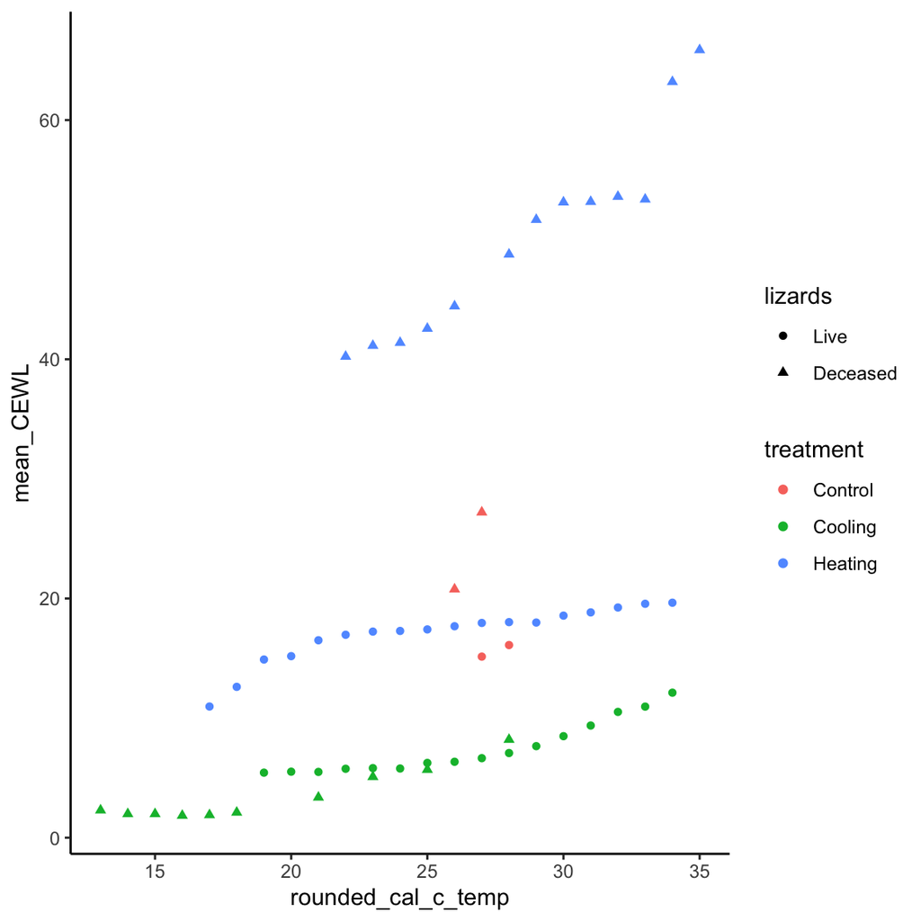

```r
ggplot(CEWL_per_temp_compare_pretty) +
  geom_point(
    aes(
      x = rounded_cal_c_temp,
      y = mean_CEWL,
      color = treatment,
      shape = lizards
    )
  ) +
  theme_classic()
```

# Export Multi-Pane Figures

## Original

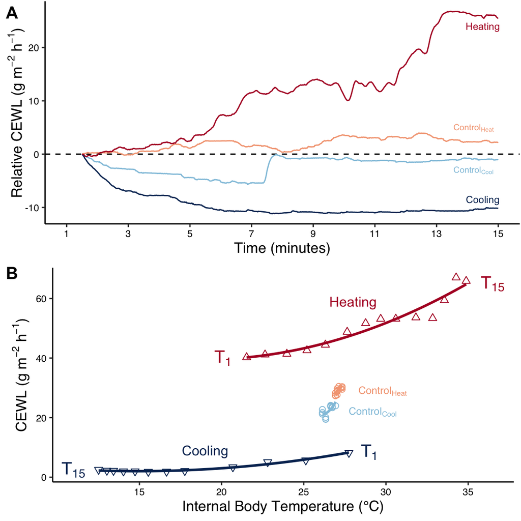

```r
# arrange
dead_arrange <- ggarrange(CEWLr_time, CEWL_ctemp,
                          nrow = 2, ncol = 1,
                          heights = c(1,1),
                          labels = c("A", "B"))
dead_arrange
```

```r
# export
ggsave(filename = "dead_lizards_time_and_temp_figs.pdf",
       plot = dead_arrange,
       path = "./Results_Figures",
       device = "pdf",
       dpi = 600,
       units = "mm",
       width = 120, height = 160)
```

## * Updated

```r
dead_arrange2 <- ggarrange(CEWLr_time,
                           dead_vs_live_fig,
                           nrow = 1, ncol = 2,
                           widths = c(1,1),
                           labels = c("(a)", "(b)"),
                           font.label = list(color = "black",
                                             face = "bold",
                                             size = 10)
                           )

# export
ggsave(filename = "dead_liz_time_temp_new.pdf",
       plot = dead_arrange2,
       path = "./Results_Figures",
       device = "pdf",
       dpi = 600,
       units = "mm",
       width = 160, height = 70)
```